# Wine

Daniel Brooks (daniel.brooks@spsmail.cuny.edu), Daniel Fanelli (daniel.fanelli@spsmail.cuny.edu), Christopher Fenton (christopher.fenton@spsmail.cuny.edu), James Hamski (james.hamski@spsmail.cuny.edu), Youqing Xiang (youqing.xiang@spsmail.cuny.edu)

7/11/2016

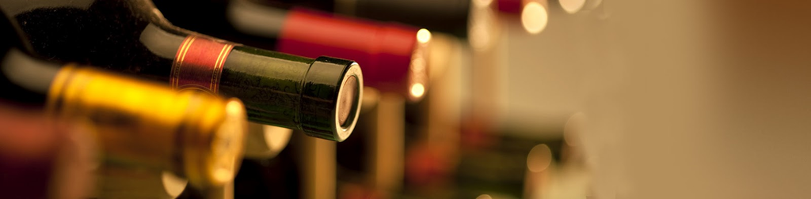

The purpose of this analysis is to develop models to predict the number of cases of wine samples a large wine manufacturer should offer to distributors to maximize wine sales.

Our data shows the chemical properties of commercially available wines as well as factors such as STARS ratings.

Our response variable is the number of sample cases purchased by distribution companies after sampling, a variable that has a direct correlation to overall wine sales. These cases are used to provide tasting samples to restaurants and wine stores around the United States. The more sample cases purchased, the more likely is a wine to be sold at a high end restaurant.

If the wine manufacturer can predict the number of cases, then that manufacturer will be able to adjust their wine offering to maximize sales.

Our training dataset includes information on 12795 wines. Each wine has 14 potential predictor variables, and 1 response variable. The response variable is “TARGET”, which is the number of cases purchased.

# 1) Data Exploration

A basic analysis of the numerical variables is below:

**WINE Data Histograms**

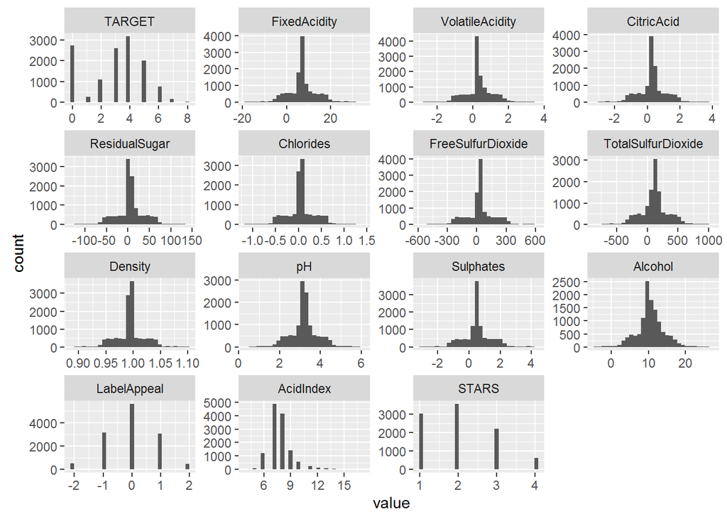

**WINE Data BoxPlots**

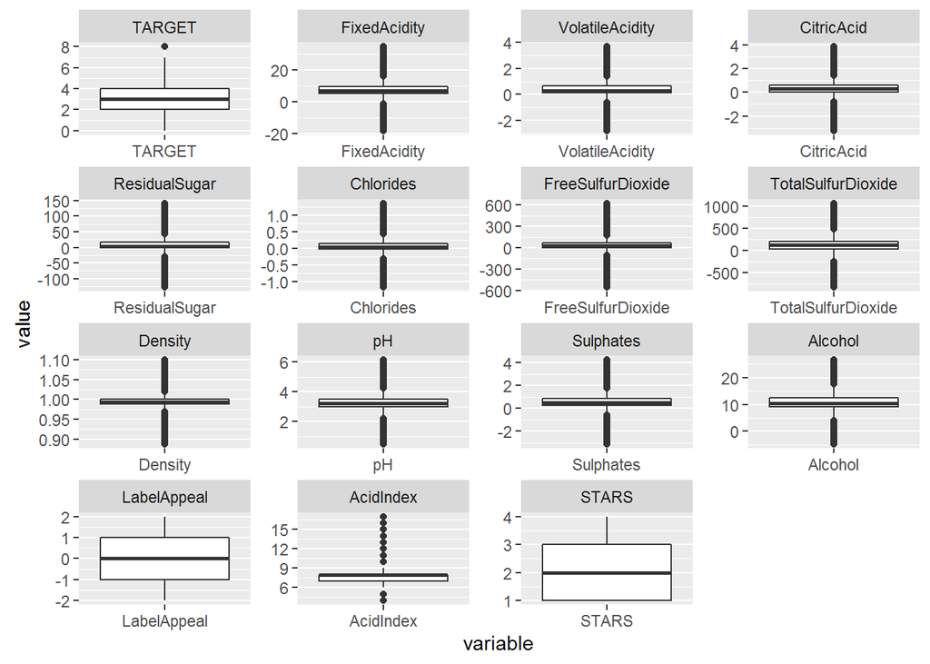

### Explore NA’s:

The below table shows a summary of the NA values in the data. Only STARS had an NA frequency higher than 10%, so this was a concern. All NA values were thus replaced with samples from their respective collections, except for STARS, which required further analysis.

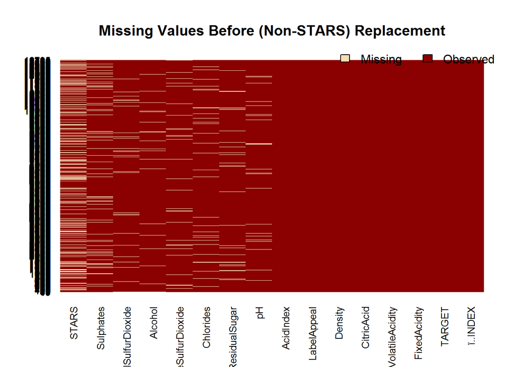

|  | not_na_count | na_count | na_pct |
| --- | --- | --- | --- |
| ï..INDEX | 12795 | 0 | 0.0000000 |
| TARGET | 12795 | 0 | 0.0000000 |
| FixedAcidity | 12795 | 0 | 0.0000000 |
| VolatileAcidity | 12795 | 0 | 0.0000000 |
| CitricAcid | 12795 | 0 | 0.0000000 |
| ResidualSugar | 12179 | 616 | 0.0481438 |
| Chlorides | 12157 | 638 | 0.0498632 |
| FreeSulfurDioxide | 12148 | 647 | 0.0505666 |
| TotalSulfurDioxide | 12113 | 682 | 0.0533021 |
| Density | 12795 | 0 | 0.0000000 |
| pH | 12400 | 395 | 0.0308714 |
| Sulphates | 11585 | 1210 | 0.0945682 |
| Alcohol | 12142 | 653 | 0.0510356 |
| LabelAppeal | 12795 | 0 | 0.0000000 |
| AcidIndex | 12795 | 0 | 0.0000000 |
| STARS | 9436 | 3359 | 0.2625244 |

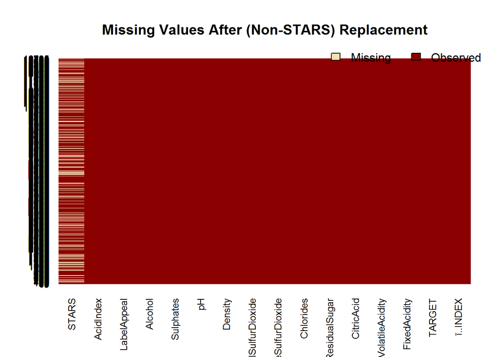

### Corrlation and Covariance:

There does not seem to be much correlation, much less any multi-collinearity issues:

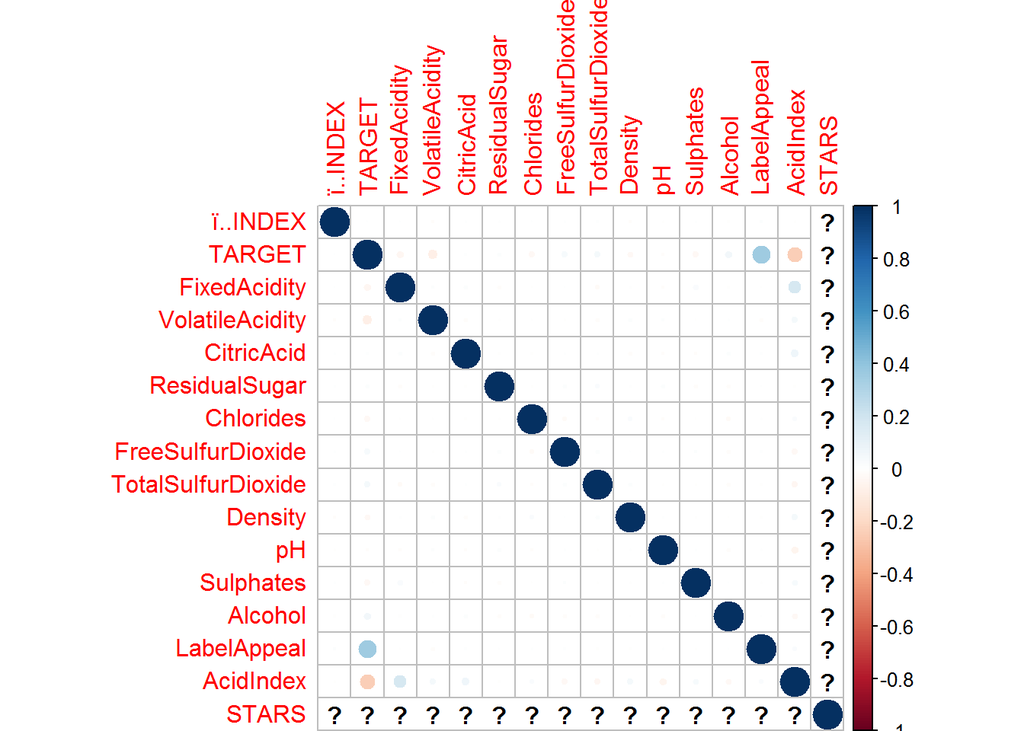

*Summary of Wine Data Correlation:*

See the mean correlation for each column. Each is near zero, showing us that the columns themselves are independent.

```
##     ï..INDEX             TARGET           FixedAcidity
##  Min.   :-0.016514   Min.   :-0.161101   Min.   :-0.018734
##  1st Qu.:-0.004838   1st Qu.:-0.020552   1st Qu.:-0.008536
##  Median : 0.002738   Median : 0.006605   Median :-0.001128
##  Mean   : 0.064922   Mean   : 0.118689   Mean   : 0.071670
##  3rd Qu.: 0.010995   3rd Qu.: 0.035128   3rd Qu.: 0.012447
##  Max.   : 1.000000   Max.   : 1.000000   Max.   : 1.000000
##  VolatileAcidity       CitricAcid       ResidualSugar
##  Min.   :-0.070884   Min.   :-0.02178   Min.   :-0.016776
##  1st Qu.:-0.013657   1st Qu.:-0.01062   1st Qu.:-0.005990
##  Median :-0.001096   Median : 0.00337   Median : 0.002589
##  Mean   : 0.056723   Mean   : 0.06514   Mean   : 0.065079
##  3rd Qu.: 0.010775   3rd Qu.: 0.01179   3rd Qu.: 0.013530
##  Max.   : 1.000000   Max.   : 1.00000   Max.   : 1.000000
##    Chlorides         FreeSulfurDioxide   TotalSulfurDioxide
##  Min.   :-0.026006   Min.   :-0.018886   Min.   :-0.0205080
##  1st Qu.:-0.010679   1st Qu.:-0.010731   1st Qu.:-0.0074519
##  Median :-0.002980   Median : 0.008566   Median : 0.0008425
##  Mean   : 0.058134   Mean   : 0.065548   Mean   : 0.0640462
##  3rd Qu.: 0.004386   3rd Qu.: 0.013972   3rd Qu.: 0.0168413
##  Max.   : 1.000000   Max.   : 1.000000   Max.   : 1.0000000
##     Density                 pH              Sulphates
##  Min.   :-0.0323320   Min.   :-0.065126   Min.   :-0.0179845
##  1st Qu.:-0.0094014   1st Qu.:-0.009049   1st Qu.:-0.0057809
##  Median : 0.0001425   Median :-0.002008   Median :-0.0008404
##  Mean   : 0.0639418   Mean   : 0.056992   Mean   : 0.0640109
##  3rd Qu.: 0.0154137   3rd Qu.: 0.005814   3rd Qu.: 0.0096576
##  Max.   : 1.0000000   Max.   : 1.000000   Max.   : 1.0000000
##     Alcohol           LabelAppeal          AcidIndex
##  Min.   :-0.050569   Min.   :-0.019551   Min.   :-0.1611010
##  1st Qu.:-0.015227   1st Qu.:-0.002415   1st Qu.:-0.0280231
##  Median :-0.004026   Median : 0.005736   Median :-0.0005163
##  Mean   : 0.062740   Mean   : 0.117656   Mean   : 0.0567852
##  3rd Qu.: 0.009395   3rd Qu.: 0.015651   3rd Qu.: 0.0378943
##  Max.   : 1.000000   Max.   : 1.000000   Max.   : 1.0000000
##      STARS
##  Min.   :-0.0862589
##  1st Qu.:-0.0112274
##  Median : 0.0004292
##  Mean   : 0.1130674
##  3rd Qu.: 0.0274926
##  Max.   : 1.0000000
```

*Scatterplot of Wine Data:*

This figure also serves to show the general horizontal (lack of) correlation between columns.

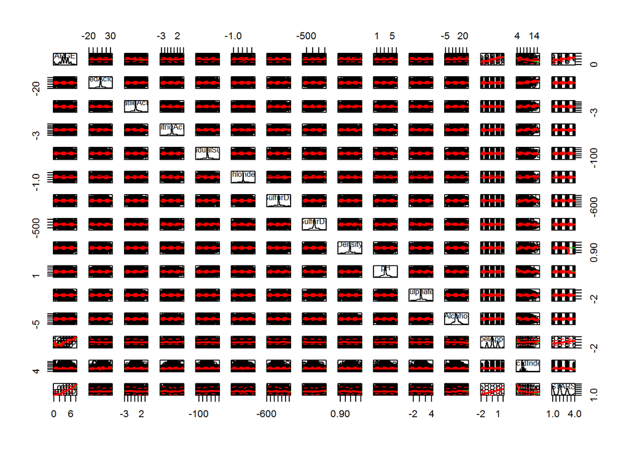

*Summary of Wine Data Covariance:*

Most of the covariances are low, though a few stick out as possibly high.

```
##     ï..INDEX            TARGET           FixedAcidity
##  Min.   :     -72   Min.   : -0.29481   Min.   :-26.87035
##  1st Qu.:     -14   1st Qu.: -0.01606   1st Qu.: -0.19354
##  Median :       4   Median :  0.19088   Median : -0.00912
##  Mean   : 1338239   Mean   : 11.01618   Mean   :  0.70947
##  3rd Qu.:     544   3rd Qu.:  1.18963   3rd Qu.:  0.09209
##  Max.   :21396100   Max.   :161.04070   Max.   : 39.46245
##  VolatileAcidity        CitricAcid       ResidualSugar
##  Min.   :-25.553108   Min.   :-0.37570   Min.   :  -2.1180
##  1st Qu.: -0.039650   1st Qu.:-0.00444   1st Qu.:  -0.2280
##  Median : -0.005640   Median : 0.00943   Median :   0.0811
##  Mean   : -1.744228   Mean   : 2.96879   Mean   : 192.7599
##  3rd Qu.:  0.008261   3rd Qu.: 0.06508   3rd Qu.:  20.2138
##  Max.   :  0.608814   Max.   :45.54073   Max.   :1693.2040
##    Chlorides         FreeSulfurDioxide   TotalSulfurDioxide
##  Min.   :-0.894237   Min.   :   -6.199   Min.   :  -26.87
##  1st Qu.:-0.015187   1st Qu.:   -1.012   1st Qu.:   -1.22
##  Median :-0.001972   Median :    1.546   Median :    0.09
##  Mean   : 0.422861   Mean   : 1693.404   Mean   : 3963.66
##  3rd Qu.: 0.000512   3rd Qu.:   27.013   3rd Qu.:   48.97
##  Max.   : 7.737069   Max.   :22358.919   Max.   :53073.34
##     Density                 pH              Sulphates
##  Min.   :-1.2940244   Min.   :-51.79316   Min.   :-4.359194
##  1st Qu.:-0.0003857   1st Qu.: -0.04229   1st Qu.:-0.008637
##  Median :-0.0000049   Median : -0.00097   Median :-0.000927
##  Mean   :-0.0717943   Mean   : -3.28008   Mean   : 0.018246
##  3rd Qu.: 0.0008329   3rd Qu.:  0.00361   3rd Qu.: 0.060402
##  Max.   : 0.1180203   Max.   :  0.56326   Max.   : 3.652259
##     Alcohol           LabelAppeal         AcidIndex
##  Min.   :-71.59716   Min.   :-0.91043   Min.   :-37.86421
##  1st Qu.: -0.69906   1st Qu.:-0.00304   1st Qu.: -0.24099
##  Median : -0.01985   Median : 0.00713   Median : -0.02542
##  Mean   : -4.92682   Mean   : 5.22437   Mean   : -2.79025
##  3rd Qu.:  0.02832   3rd Qu.: 0.37402   3rd Qu.:  0.02519
##  Max.   : 14.00050   Max.   :80.89284   Max.   :  1.38969
##      STARS
##  Min.   :-1.432531
##  1st Qu.:-0.014265
##  Median : 0.000576
##  Mean   : 0.318407
##  3rd Qu.: 0.488300
##  Max.   : 3.427347
```

# 2) Data Preparation

### Looking for Patterns in the ‘STARS’ NA Values:

Note that there are no ZEROS in the STARS field, 1 is the min:

```
## [1] 1
```

Graphically, it seems that a blank stars field is analagous to a ZERO (see chart below).

```
##   num_stars mean_target
## 1         0    1.183686
## 2         1    2.580539
## 3         2    3.798319
## 4         3    4.544756
## 5         4    5.421569
```

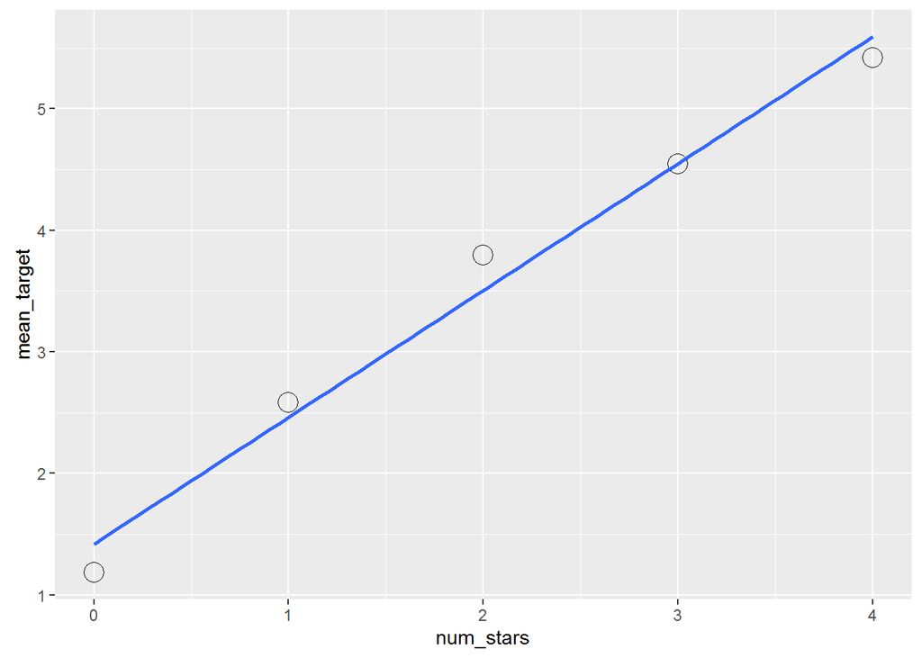

Though this calculation may be imperfect at the moment, we will show later that the calculation is to be discarded, and thus not worth figuring out a closer approximation for NA’s replacement in the *STARS* field.

After the fill, we have what looks like a *Zero-Inflated* model on our hands.

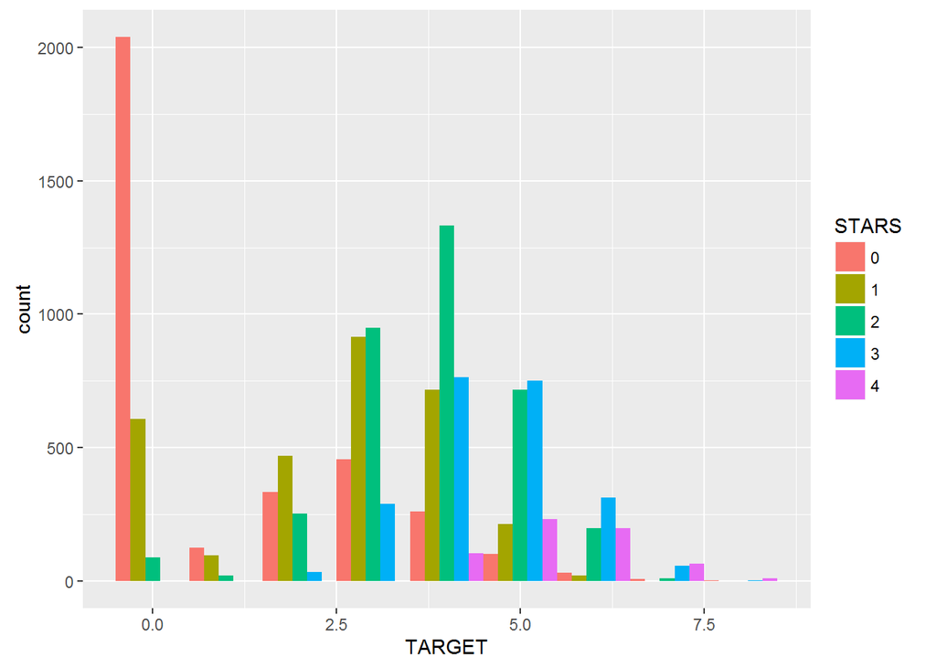

# 3) Build Models

We will build 4 data sets from our training data:

- TRAINING set where NAs were replaced by ZEROs in the SCORE column.
- TRAINING set where NAs were *NOT* replaced by ZEROs in the SCORE column.
- TEST set where NAs were replaced by ZEROs in the SCORE column.
- TEST set where NAs were *NOT* replaced by ZEROs in the SCORE column.

Simple Step Selection will be used for attribute selection, and we will build 3 models for both sets, plus a “zerinfl” negative binomial, yielding a total of 7 models:

- *A Poisson GLM with SCORE: “Zeros-for-NAs”*
- *A Poisson GLM with SCORE: “NAs Removed”*
- *A Negative Binomial GLM with SCORE: “Zeros-for-NAs”*
- *A Negative Binomial GLM with SCORE: “NAs Removed”*
- *A Multiple Linear Regression Model with SCORE: “Zeros-for-NAs”*
- *A Multiple Linear Regression Model with SCORE: “NAs Removed”*
- *A Negative Binomial Model via “zeroinfl()”: “Zeros-for-NAs”*

*Summaries for these Models are below:*

(To show our point regarding coefficients, we will show summaries for the 2 Negative Binomial Distributions. Summaries of all 7 models, however, are located in the appendix).

```r
fit.nb.zeros <- step(glm.nb(TARGET ~ . , data = wine.zeros.train), trace = FALSE)
summary(fit.nb.zeros)
```

```
##
## Call:
## glm.nb(formula = TARGET ~ VolatileAcidity + Chlorides + FreeSulfurDioxide +
##     TotalSulfurDioxide + Sulphates + Alcohol + LabelAppeal +
##     AcidIndex + STARS, data = wine.zeros.train, init.theta = 41514.10176,
##     link = log)
##
## Deviance Residuals:
##     Min       1Q   Median       3Q      Max
## -3.2438  -0.6343   0.0000   0.4417   3.6262
##
## Coefficients:
##                      Estimate Std. Error z value Pr(>|z|)
## (Intercept)         1.282e-01  3.206e-01   0.400  0.68936
## VolatileAcidity    -3.158e-02  7.557e-03  -4.179 2.93e-05 ***
## Chlorides          -2.635e-02  1.856e-02  -1.420  0.15563
## FreeSulfurDioxide   7.373e-05  3.951e-05   1.866  0.06204 .
## TotalSulfurDioxide  6.000e-05  2.545e-05   2.357  0.01840 *
## Sulphates          -1.113e-02  6.244e-03  -1.783  0.07459 .
## Alcohol             4.129e-03  1.594e-03   2.590  0.00959 **
## LabelAppeal-1       2.654e-01  4.400e-02   6.032 1.62e-09 ***
## LabelAppeal0        4.498e-01  4.295e-02  10.474  < 2e-16 ***
## LabelAppeal1        5.914e-01  4.366e-02  13.544  < 2e-16 ***
## LabelAppeal2        7.323e-01  4.930e-02  14.854  < 2e-16 ***
## AcidIndex5         -3.285e-01  3.252e-01  -1.010  0.31241
## AcidIndex6         -2.606e-01  3.173e-01  -0.821  0.41150
## AcidIndex7         -2.999e-01  3.170e-01  -0.946  0.34396
## AcidIndex8         -3.276e-01  3.170e-01  -1.034  0.30136
## AcidIndex9         -4.443e-01  3.174e-01  -1.400  0.16155
## AcidIndex10        -5.954e-01  3.189e-01  -1.867  0.06192 .
## AcidIndex11        -9.203e-01  3.231e-01  -2.848  0.00440 **
## AcidIndex12        -9.075e-01  3.300e-01  -2.750  0.00596 **
## AcidIndex13        -7.682e-01  3.332e-01  -2.306  0.02112 *
## AcidIndex14        -9.947e-01  3.533e-01  -2.815  0.00487 **
## AcidIndex15        -3.320e-01  4.290e-01  -0.774  0.43895
## AcidIndex16        -3.787e+01  3.355e+07   0.000  1.00000
## AcidIndex17        -1.275e+00  5.484e-01  -2.324  0.02011 *
## STARS1              7.279e-01  2.263e-02  32.167  < 2e-16 ***
## STARS2              1.057e+00  2.114e-02  50.006  < 2e-16 ***
## STARS3              1.169e+00  2.226e-02  52.515  < 2e-16 ***
## STARS4              1.299e+00  2.808e-02  46.247  < 2e-16 ***
## ---
## Signif. codes:  0 '***' 0.001 '**' 0.01 '*' 0.05 '.' 0.1 ' ' 1
##
## (Dispersion parameter for Negative Binomial(41514.11) family taken to be 1)
##
##     Null deviance: 17041  on 9595  degrees of freedom
## Residual deviance: 10187  on 9568  degrees of freedom
## AIC: 34239
##
## Number of Fisher Scoring iterations: 1
##
##
##               Theta:  41514
##           Std. Err.:  40651
## Warning while fitting theta: alternation limit reached
##
##  2 x log-likelihood:  -34181.45
```

```r
fit.nb.nozeros <- step(glm.nb(TARGET ~ . , data = wine.nozeros.train), trace = FALSE)
summary(fit.nb.nozeros)
```

```
##
## Call:
## glm.nb(formula = TARGET ~ VolatileAcidity + FreeSulfurDioxide +
##     Alcohol + LabelAppeal + AcidIndex + STARS, data = wine.nozeros.train,
##     init.theta = 132287.7282, link = log)
##
## Deviance Residuals:
##     Min       1Q   Median       3Q      Max
## -3.2625  -0.2646   0.0495   0.3996   1.7754
##
## Coefficients:
##                     Estimate Std. Error z value Pr(>|z|)
## (Intercept)        3.213e-01  4.511e-01   0.712  0.47630
## VolatileAcidity   -2.556e-02  8.013e-03  -3.190  0.00143 **
## FreeSulfurDioxide  6.558e-05  4.184e-05   1.568  0.11697
## Alcohol            4.888e-03  1.690e-03   2.892  0.00383 **
## LabelAppeal-1      2.961e-01  5.113e-02   5.790 7.03e-09 ***
## LabelAppeal0       5.110e-01  4.998e-02  10.224  < 2e-16 ***
## LabelAppeal1       6.691e-01  5.064e-02  13.213  < 2e-16 ***
## LabelAppeal2       8.106e-01  5.589e-02  14.504  < 2e-16 ***
## AcidIndex5         1.599e-01  4.540e-01   0.352  0.72474
## AcidIndex6         1.842e-01  4.482e-01   0.411  0.68110
## AcidIndex7         1.543e-01  4.479e-01   0.344  0.73056
## AcidIndex8         1.282e-01  4.480e-01   0.286  0.77465
## AcidIndex9         6.773e-02  4.483e-01   0.151  0.87990
## AcidIndex10       -2.310e-02  4.496e-01  -0.051  0.95903
## AcidIndex11       -1.779e-01  4.527e-01  -0.393  0.69432
## AcidIndex12       -1.283e-01  4.591e-01  -0.279  0.77998
## AcidIndex13       -1.036e-01  4.599e-01  -0.225  0.82171
## AcidIndex14       -4.625e-01  4.816e-01  -0.960  0.33681
## AcidIndex15        8.879e-02  5.587e-01   0.159  0.87372
## AcidIndex16       -3.765e+01  5.917e+07   0.000  1.00000
## AcidIndex17        6.721e-03  6.336e-01   0.011  0.99154
## STARS2             3.282e-01  1.665e-02  19.707  < 2e-16 ***
## STARS3             4.390e-01  1.818e-02  24.146  < 2e-16 ***
## STARS4             5.646e-01  2.517e-02  22.434  < 2e-16 ***
## ---
## Signif. codes:  0 '***' 0.001 '**' 0.01 '*' 0.05 '.' 0.1 ' ' 1
##
## (Dispersion parameter for Negative Binomial(132287.5) family taken to be 1)
##
##     Null deviance: 6582.8  on 7076  degrees of freedom
## Residual deviance: 4341.3  on 7053  degrees of freedom
## AIC: 25370
##
## Number of Fisher Scoring iterations: 1
##
##
##               Theta:  132288
##           Std. Err.:  202830
## Warning while fitting theta: alternation limit reached
##
##  2 x log-likelihood:  -25319.84
```

### Some Notes on the Models

- Though the 5th and 6th models are not GLMs, and thus should be used with normal distributions, we need to remember that the TARGET variable did have a normal distribution before the ZEROS replaced the NAs in the SCORE column.
- There seem to be MORE significant fields in the “with zeros” model than in the “no zeros” model. Will this mean higher accuracy?

[output not shown]

## Model Co-efficients

(Similar observations hold for the 4 models not shown also)

Note that STARS1 has a huge increase in impact in the first fit, showing what an impact that NA to Zero translation had. (We’ll see soon whether that impact was one of clarifying or confusing.)

# 4) Select Models

Before selecting a model, a quick explanation of why the “no ZEROs” models performed better:

One might think that either removing or keeping a value (such as the “Perfect-Graphical-Fit” Zeros-for-NAs) would possibly *improve* a model’s accuracy, but at least *maintain* it. In this case, however, we saw a relatively large drop in performance of the models due to the inclusion of this attribute. Why would this be?

One probable explanation is that true customers that actually *BOUGHT* the product took the time to fill their surveys out accurately. Customers who didn’t purchase the product (with less stake in the game and/or lack of knowledge of the product) simply did not contribute such useful data. Due to this, the Zero-Inflated model is basically gone, and a linear model with a normal distribution again seems reasonable.

We know that Poisson Regression is actually a special case of Negative Binomial Regression (where the mean and the variance are equal), but in this case, the Poisson Regression did not yield more accurate results. We know that if there is overdispersion in the Poisson, then the estimates from the Poisson regression model are consistent but inefficient. It seems from our Box Plots in Figure 1.2 that these overdispersions may have occurred.

“[When comparing models fitted by maximum likelihood to the same data, the smaller the AIC or BIC, the better the fit.](https://stat.ethz.ch/R-manual/R-devel/library/stats/html/AIC.html)”"

Our results have been written to *DATA621-HW-5-RESULTS.csv*, and a sampling is shown below:

```
##   1   2   3   4   5   6   7   8   9  10  11  12  13  14  15  16  17  18
##   1   4   3   2   1   6   2   2   1   1   0   1   4   0   1   2   2   1
##  19  20  21  22  23  24  25  26  27  28  29  30  31  32  33  34  35  36
##   4   5   2   1   2   2   4   5   3   6   5   2   0   1   5   3   1   4
##  37  38  39  40  41  42  43  44  45  46  47  48  49  50  51  52  53  54
##   3   4   1   1   2   0   1   1   0   4   3   5   4   2   4   0   4   1
##  55  56  57  58  59  60  61  62  63  64  65  66  67  68  69  70  71  72
##   2   0   0   4   1   1   0   0   0   2   3   2   4   5   1   4   0   0
##  73  74  75  76  77  78  79  80  81  82  83  84  85  86  87  88  89  90
##   2   5   2   3   0   0   5   0   2   2   2   2   3   4   3   5   0   5
##  91  92  93  94  95  96  97  98  99 100
##   2   1   1   4   2   0   4   3   3   1
```

# Appendix

## Summaries of all 7 Models:

```
##
## Call:
## glm(formula = TARGET ~ VolatileAcidity + FreeSulfurDioxide +
##     Alcohol + LabelAppeal + AcidIndex + STARS, family = poisson,
##     data = wine.nozeros.train)
##
## Deviance Residuals:
##     Min       1Q   Median       3Q      Max
## -3.2625  -0.2646   0.0495   0.3996   1.7754
##
## Coefficients:
##                     Estimate Std. Error z value Pr(>|z|)
## (Intercept)        3.213e-01  4.511e-01   0.712  0.47630
## VolatileAcidity   -2.556e-02  8.013e-03  -3.190  0.00143 **
## FreeSulfurDioxide  6.558e-05  4.184e-05   1.568  0.11696
## Alcohol            4.888e-03  1.690e-03   2.892  0.00383 **
## LabelAppeal-1      2.961e-01  5.113e-02   5.790 7.02e-09 ***
## LabelAppeal0       5.110e-01  4.998e-02  10.224  < 2e-16 ***
## LabelAppeal1       6.691e-01  5.064e-02  13.213  < 2e-16 ***
## LabelAppeal2       8.106e-01  5.589e-02  14.504  < 2e-16 ***
## AcidIndex5         1.599e-01  4.540e-01   0.352  0.72474
## AcidIndex6         1.842e-01  4.482e-01   0.411  0.68109
## AcidIndex7         1.543e-01  4.479e-01   0.344  0.73055
## AcidIndex8         1.282e-01  4.479e-01   0.286  0.77465
## AcidIndex9         6.773e-02  4.483e-01   0.151  0.87990
## AcidIndex10       -2.310e-02  4.496e-01  -0.051  0.95903
## AcidIndex11       -1.779e-01  4.527e-01  -0.393  0.69432
## AcidIndex12       -1.282e-01  4.591e-01  -0.279  0.77998
## AcidIndex13       -1.036e-01  4.599e-01  -0.225  0.82171
## AcidIndex14       -4.625e-01  4.816e-01  -0.961  0.33680
## AcidIndex15        8.879e-02  5.587e-01   0.159  0.87371
## AcidIndex16       -1.216e+01  1.727e+02  -0.070  0.94385
## AcidIndex17        6.721e-03  6.336e-01   0.011  0.99154
## STARS2             3.282e-01  1.665e-02  19.707  < 2e-16 ***
## STARS3             4.390e-01  1.818e-02  24.146  < 2e-16 ***
## STARS4             5.646e-01  2.517e-02  22.435  < 2e-16 ***
## ---
## Signif. codes:  0 '***' 0.001 '**' 0.01 '*' 0.05 '.' 0.1 ' ' 1
##
## (Dispersion parameter for poisson family taken to be 1)
##
##     Null deviance: 6583.0  on 7076  degrees of freedom
## Residual deviance: 4341.3  on 7053  degrees of freedom
## AIC: 25368
##
## Number of Fisher Scoring iterations: 9
```

```
##
## Call:
## glm.nb(formula = TARGET ~ VolatileAcidity + FreeSulfurDioxide +
##     Alcohol + LabelAppeal + AcidIndex + STARS, data = wine.nozeros.train,
##     init.theta = 132287.7282, link = log)
##
## Deviance Residuals:
##     Min       1Q   Median       3Q      Max
## -3.2625  -0.2646   0.0495   0.3996   1.7754
##
## Coefficients:
##                     Estimate Std. Error z value Pr(>|z|)
## (Intercept)        3.213e-01  4.511e-01   0.712  0.47630
## VolatileAcidity   -2.556e-02  8.013e-03  -3.190  0.00143 **
## FreeSulfurDioxide  6.558e-05  4.184e-05   1.568  0.11697
## Alcohol            4.888e-03  1.690e-03   2.892  0.00383 **
## LabelAppeal-1      2.961e-01  5.113e-02   5.790 7.03e-09 ***
## LabelAppeal0       5.110e-01  4.998e-02  10.224  < 2e-16 ***
## LabelAppeal1       6.691e-01  5.064e-02  13.213  < 2e-16 ***
## LabelAppeal2       8.106e-01  5.589e-02  14.504  < 2e-16 ***
## AcidIndex5         1.599e-01  4.540e-01   0.352  0.72474
## AcidIndex6         1.842e-01  4.482e-01   0.411  0.68110
## AcidIndex7         1.543e-01  4.479e-01   0.344  0.73056
## AcidIndex8         1.282e-01  4.480e-01   0.286  0.77465
## AcidIndex9         6.773e-02  4.483e-01   0.151  0.87990
## AcidIndex10       -2.310e-02  4.496e-01  -0.051  0.95903
## AcidIndex11       -1.779e-01  4.527e-01  -0.393  0.69432
## AcidIndex12       -1.283e-01  4.591e-01  -0.279  0.77998
## AcidIndex13       -1.036e-01  4.599e-01  -0.225  0.82171
## AcidIndex14       -4.625e-01  4.816e-01  -0.960  0.33681
## AcidIndex15        8.879e-02  5.587e-01   0.159  0.87372
## AcidIndex16       -3.765e+01  5.917e+07   0.000  1.00000
## AcidIndex17        6.721e-03  6.336e-01   0.011  0.99154
## STARS2             3.282e-01  1.665e-02  19.707  < 2e-16 ***
## STARS3             4.390e-01  1.818e-02  24.146  < 2e-16 ***
## STARS4             5.646e-01  2.517e-02  22.434  < 2e-16 ***
## ---
## Signif. codes:  0 '***' 0.001 '**' 0.01 '*' 0.05 '.' 0.1 ' ' 1
##
## (Dispersion parameter for Negative Binomial(132287.5) family taken to be 1)
##
##     Null deviance: 6582.8  on 7076  degrees of freedom
## Residual deviance: 4341.3  on 7053  degrees of freedom
## AIC: 25370
##
## Number of Fisher Scoring iterations: 1
##
##
##               Theta:  132288
##           Std. Err.:  202830
## Warning while fitting theta: alternation limit reached
##
##  2 x log-likelihood:  -25319.84
```

```
##
## Call:
## lm(formula = TARGET ~ VolatileAcidity + Chlorides + FreeSulfurDioxide +
##     Density + Alcohol + LabelAppeal + AcidIndex + STARS, data = wine.nozeros.train)
##
## Residuals:
##     Min      1Q  Median      3Q     Max
## -5.3265 -0.5309  0.1035  0.7415  3.1704
##
## Coefficients:
##                     Estimate Std. Error t value Pr(>|t|)
## (Intercept)        1.7441168  1.2537045   1.391  0.16422
## VolatileAcidity   -0.0938699  0.0174542  -5.378 7.77e-08 ***
## Chlorides         -0.0652280  0.0431636  -1.511  0.13079
## FreeSulfurDioxide  0.0002448  0.0000917   2.670  0.00761 **
## Density           -1.0566689  0.5144200  -2.054  0.04000 *
## Alcohol            0.0175970  0.0036616   4.806 1.57e-06 ***
## LabelAppeal-1      0.6072326  0.0817505   7.428 1.23e-13 ***
## LabelAppeal0       1.2563502  0.0798857  15.727  < 2e-16 ***
## LabelAppeal1       1.9129230  0.0827350  23.121  < 2e-16 ***
## LabelAppeal2       2.6593922  0.1046463  25.413  < 2e-16 ***
## AcidIndex5         0.7556331  1.1591491   0.652  0.51450
## AcidIndex6         0.8592392  1.1471122   0.749  0.45385
## AcidIndex7         0.7439094  1.1465539   0.649  0.51647
## AcidIndex8         0.6409111  1.1466203   0.559  0.57621
## AcidIndex9         0.4347493  1.1471806   0.379  0.70472
## AcidIndex10        0.1483754  1.1491953   0.129  0.89727
## AcidIndex11       -0.2443920  1.1526964  -0.212  0.83210
## AcidIndex12       -0.1689463  1.1624292  -0.145  0.88445
## AcidIndex13       -0.0855716  1.1635518  -0.074  0.94138
## AcidIndex14       -0.7996476  1.1779865  -0.679  0.49727
## AcidIndex15        0.4331384  1.3240407   0.327  0.74358
## AcidIndex16       -2.0413926  1.6206483  -1.260  0.20785
## AcidIndex17        0.1659811  1.6232511   0.102  0.91856
## STARS2             1.0112765  0.0331433  30.512  < 2e-16 ***
## STARS3             1.4979708  0.0385979  38.810  < 2e-16 ***
## STARS4             2.1741178  0.0612765  35.480  < 2e-16 ***
## ---
## Signif. codes:  0 '***' 0.001 '**' 0.01 '*' 0.05 '.' 0.1 ' ' 1
##
## Residual standard error: 1.145 on 7051 degrees of freedom
## Multiple R-squared:  0.4647, Adjusted R-squared:  0.4628
## F-statistic: 244.8 on 25 and 7051 DF,  p-value: < 2.2e-16
```

```
##
## Call:
## glm(formula = TARGET ~ VolatileAcidity + Chlorides + FreeSulfurDioxide +
##     TotalSulfurDioxide + Sulphates + Alcohol + LabelAppeal +
##     AcidIndex + STARS, family = poisson, data = wine.zeros.train)
##
## Deviance Residuals:
##     Min       1Q   Median       3Q      Max
## -3.2439  -0.6344  -0.0009   0.4417   3.6263
##
## Coefficients:
##                      Estimate Std. Error z value Pr(>|z|)
## (Intercept)         1.281e-01  3.206e-01   0.400  0.68943
## VolatileAcidity    -3.158e-02  7.556e-03  -4.179 2.93e-05 ***
## Chlorides          -2.635e-02  1.856e-02  -1.420  0.15563
## FreeSulfurDioxide   7.373e-05  3.951e-05   1.866  0.06204 .
## TotalSulfurDioxide  6.000e-05  2.545e-05   2.357  0.01840 *
## Sulphates          -1.113e-02  6.244e-03  -1.783  0.07459 .
## Alcohol             4.130e-03  1.594e-03   2.590  0.00959 **
## LabelAppeal-1       2.654e-01  4.400e-02   6.033 1.61e-09 ***
## LabelAppeal0        4.498e-01  4.295e-02  10.474  < 2e-16 ***
## LabelAppeal1        5.914e-01  4.366e-02  13.544  < 2e-16 ***
## LabelAppeal2        7.323e-01  4.930e-02  14.854  < 2e-16 ***
## AcidIndex5         -3.284e-01  3.252e-01  -1.010  0.31244
## AcidIndex6         -2.606e-01  3.173e-01  -0.821  0.41154
## AcidIndex7         -2.999e-01  3.169e-01  -0.946  0.34400
## AcidIndex8         -3.276e-01  3.170e-01  -1.033  0.30139
## AcidIndex9         -4.443e-01  3.174e-01  -1.400  0.16156
## AcidIndex10        -5.953e-01  3.189e-01  -1.867  0.06193 .
## AcidIndex11        -9.202e-01  3.231e-01  -2.848  0.00440 **
## AcidIndex12        -9.074e-01  3.300e-01  -2.750  0.00596 **
## AcidIndex13        -7.682e-01  3.331e-01  -2.306  0.02112 *
## AcidIndex14        -9.947e-01  3.533e-01  -2.815  0.00487 **
## AcidIndex15        -3.320e-01  4.290e-01  -0.774  0.43898
## AcidIndex16        -1.316e+01  1.410e+02  -0.093  0.92562
## AcidIndex17        -1.275e+00  5.484e-01  -2.324  0.02011 *
## STARS1              7.279e-01  2.263e-02  32.168  < 2e-16 ***
## STARS2              1.057e+00  2.114e-02  50.007  < 2e-16 ***
## STARS3              1.169e+00  2.226e-02  52.517  < 2e-16 ***
## STARS4              1.299e+00  2.808e-02  46.249  < 2e-16 ***
## ---
## Signif. codes:  0 '***' 0.001 '**' 0.01 '*' 0.05 '.' 0.1 ' ' 1
##
## (Dispersion parameter for poisson family taken to be 1)
##
##     Null deviance: 17042  on 9595  degrees of freedom
## Residual deviance: 10187  on 9568  degrees of freedom
## AIC: 34237
##
## Number of Fisher Scoring iterations: 10
```

```
##
## Call:
## glm.nb(formula = TARGET ~ VolatileAcidity + Chlorides + FreeSulfurDioxide +
##     TotalSulfurDioxide + Sulphates + Alcohol + LabelAppeal +
##     AcidIndex + STARS, data = wine.zeros.train, init.theta = 41514.10176,
##     link = log)
##
## Deviance Residuals:
##     Min       1Q   Median       3Q      Max
## -3.2438  -0.6343   0.0000   0.4417   3.6262
##
## Coefficients:
##                      Estimate Std. Error z value Pr(>|z|)
## (Intercept)         1.282e-01  3.206e-01   0.400  0.68936
## VolatileAcidity    -3.158e-02  7.557e-03  -4.179 2.93e-05 ***
## Chlorides          -2.635e-02  1.856e-02  -1.420  0.15563
## FreeSulfurDioxide   7.373e-05  3.951e-05   1.866  0.06204 .
## TotalSulfurDioxide  6.000e-05  2.545e-05   2.357  0.01840 *
## Sulphates          -1.113e-02  6.244e-03  -1.783  0.07459 .
## Alcohol             4.129e-03  1.594e-03   2.590  0.00959 **
## LabelAppeal-1       2.654e-01  4.400e-02   6.032 1.62e-09 ***
## LabelAppeal0        4.498e-01  4.295e-02  10.474  < 2e-16 ***
## LabelAppeal1        5.914e-01  4.366e-02  13.544  < 2e-16 ***
## LabelAppeal2        7.323e-01  4.930e-02  14.854  < 2e-16 ***
## AcidIndex5         -3.285e-01  3.252e-01  -1.010  0.31241
## AcidIndex6         -2.606e-01  3.173e-01  -0.821  0.41150
## AcidIndex7         -2.999e-01  3.170e-01  -0.946  0.34396
## AcidIndex8         -3.276e-01  3.170e-01  -1.034  0.30136
## AcidIndex9         -4.443e-01  3.174e-01  -1.400  0.16155
## AcidIndex10        -5.954e-01  3.189e-01  -1.867  0.06192 .
## AcidIndex11        -9.203e-01  3.231e-01  -2.848  0.00440 **
## AcidIndex12        -9.075e-01  3.300e-01  -2.750  0.00596 **
## AcidIndex13        -7.682e-01  3.332e-01  -2.306  0.02112 *
## AcidIndex14        -9.947e-01  3.533e-01  -2.815  0.00487 **
## AcidIndex15        -3.320e-01  4.290e-01  -0.774  0.43895
## AcidIndex16        -3.787e+01  3.355e+07   0.000  1.00000
## AcidIndex17        -1.275e+00  5.484e-01  -2.324  0.02011 *
## STARS1              7.279e-01  2.263e-02  32.167  < 2e-16 ***
## STARS2              1.057e+00  2.114e-02  50.006  < 2e-16 ***
## STARS3              1.169e+00  2.226e-02  52.515  < 2e-16 ***
## STARS4              1.299e+00  2.808e-02  46.247  < 2e-16 ***
## ---
## Signif. codes:  0 '***' 0.001 '**' 0.01 '*' 0.05 '.' 0.1 ' ' 1
##
## (Dispersion parameter for Negative Binomial(41514.11) family taken to be 1)
##
##     Null deviance: 17041  on 9595  degrees of freedom
## Residual deviance: 10187  on 9568  degrees of freedom
## AIC: 34239
##
## Number of Fisher Scoring iterations: 1
##
##
##               Theta:  41514
##           Std. Err.:  40651
## Warning while fitting theta: alternation limit reached
##
##  2 x log-likelihood:  -34181.45
```

```
##
## Call:
## lm(formula = TARGET ~ VolatileAcidity + Chlorides + FreeSulfurDioxide +
##     TotalSulfurDioxide + Density + pH + Sulphates + Alcohol +
##     LabelAppeal + AcidIndex + STARS, data = wine.zeros.train)
##
## Residuals:
##     Min      1Q  Median      3Q     Max
## -4.9916 -0.8568  0.0479  0.8320  6.0294
##
## Coefficients:
##                      Estimate Std. Error t value Pr(>|t|)
## (Intercept)         2.749e+00  1.056e+00   2.604 0.009227 **
## VolatileAcidity    -9.872e-02  1.710e-02  -5.773 8.02e-09 ***
## Chlorides          -8.618e-02  4.204e-02  -2.050 0.040383 *
## FreeSulfurDioxide   2.160e-04  8.999e-05   2.401 0.016390 *
## TotalSulfurDioxide  1.734e-04  5.773e-05   3.004 0.002668 **
## Density            -9.229e-01  5.027e-01  -1.836 0.066409 .
## pH                 -3.533e-02  1.981e-02  -1.783 0.074562 .
## Sulphates          -3.093e-02  1.420e-02  -2.177 0.029476 *
## Alcohol             1.279e-02  3.594e-03   3.559 0.000375 ***
## LabelAppeal-1       4.075e-01  7.231e-02   5.636 1.79e-08 ***
## LabelAppeal0        8.608e-01  7.053e-02  12.206  < 2e-16 ***
## LabelAppeal1        1.354e+00  7.367e-02  18.382  < 2e-16 ***
## LabelAppeal2        1.984e+00  9.827e-02  20.193  < 2e-16 ***
## AcidIndex5         -1.249e+00  9.429e-01  -1.325 0.185324
## AcidIndex6         -1.047e+00  9.265e-01  -1.131 0.258270
## AcidIndex7         -1.171e+00  9.258e-01  -1.265 0.205742
## AcidIndex8         -1.272e+00  9.258e-01  -1.373 0.169636
## AcidIndex9         -1.587e+00  9.264e-01  -1.714 0.086644 .
## AcidIndex10        -1.890e+00  9.278e-01  -2.038 0.041627 *
## AcidIndex11        -2.340e+00  9.302e-01  -2.516 0.011886 *
## AcidIndex12        -2.300e+00  9.349e-01  -2.461 0.013890 *
## AcidIndex13        -2.365e+00  9.426e-01  -2.509 0.012140 *
## AcidIndex14        -2.316e+00  9.509e-01  -2.435 0.014906 *
## AcidIndex15        -1.265e+00  1.095e+00  -1.155 0.248182
## AcidIndex16        -3.138e+00  1.133e+00  -2.769 0.005629 **
## AcidIndex17        -2.812e+00  1.069e+00  -2.630 0.008543 **
## STARS1              1.298e+00  3.819e-02  33.996  < 2e-16 ***
## STARS2              2.358e+00  3.729e-02  63.239  < 2e-16 ***
## STARS3              2.894e+00  4.307e-02  67.181  < 2e-16 ***
## STARS4              3.623e+00  6.853e-02  52.865  < 2e-16 ***
## ---
## Signif. codes:  0 '***' 0.001 '**' 0.01 '*' 0.05 '.' 0.1 ' ' 1
##
## Residual standard error: 1.307 on 9566 degrees of freedom
## Multiple R-squared:  0.5387, Adjusted R-squared:  0.5373
## F-statistic: 385.2 on 29 and 9566 DF,  p-value: < 2.2e-16
```

```
##
## Call:
## zeroinfl(formula = TARGET ~ VolatileAcidity + Chlorides + FreeSulfurDioxide +
##     Density + Alcohol + LabelAppeal + AcidIndex + STARS | STARS,
##     data = wine.zeros.train, dist = "negbin")
##
## Pearson residuals:
##      Min       1Q   Median       3Q      Max
## -2.35794 -0.52887  0.01751  0.44635  2.70416
##
## Count model coefficients (negbin with log link):
##                     Estimate Std. Error z value Pr(>|z|)
## (Intercept)        7.153e-01  3.903e-01   1.833   0.0668 .
## VolatileAcidity   -1.504e-02  7.718e-03  -1.949   0.0513 .
## Chlorides         -1.862e-02  1.895e-02  -0.983   0.3256
## FreeSulfurDioxide  3.704e-05  3.970e-05   0.933   0.3508
## Density           -2.376e-01  2.267e-01  -1.048   0.2946
## Alcohol            6.575e-03  1.623e-03   4.050 5.11e-05 ***
## LabelAppeal-1      3.753e-01  4.538e-02   8.270  < 2e-16 ***
## LabelAppeal0       6.458e-01  4.441e-02  14.540  < 2e-16 ***
## LabelAppeal1       8.321e-01  4.521e-02  18.405  < 2e-16 ***
## LabelAppeal2       9.920e-01  5.079e-02  19.531  < 2e-16 ***
## AcidIndex5         8.843e-04  3.255e-01   0.003   0.9978
## AcidIndex6         3.777e-02  3.175e-01   0.119   0.9053
## AcidIndex7         8.832e-03  3.171e-01   0.028   0.9778
## AcidIndex8        -5.542e-03  3.172e-01  -0.017   0.9861
## AcidIndex9        -5.425e-02  3.176e-01  -0.171   0.8644
## AcidIndex10       -1.153e-01  3.194e-01  -0.361   0.7180
## AcidIndex11       -2.291e-01  3.255e-01  -0.704   0.4815
## AcidIndex12       -1.473e-01  3.348e-01  -0.440   0.6600
## AcidIndex13       -9.181e-02  3.372e-01  -0.272   0.7854
## AcidIndex14       -1.911e-01  3.803e-01  -0.503   0.6153
## AcidIndex15        1.324e-01  4.434e-01   0.299   0.7652
## AcidIndex16       -1.316e+01  2.705e+02  -0.049   0.9612
## AcidIndex17       -2.472e-01  6.191e-01  -0.399   0.6897
## STARS1             2.937e-02  2.439e-02   1.204   0.2284
## STARS2             1.552e-01  2.251e-02   6.893 5.47e-12 ***
## STARS3             2.547e-01  2.377e-02  10.714  < 2e-16 ***
## STARS4             3.697e-01  2.940e-02  12.575  < 2e-16 ***
## Log(theta)         1.892e+01  1.542e+00  12.268  < 2e-16 ***
##
## Zero-inflation model coefficients (binomial with logit link):
##              Estimate Std. Error z value Pr(>|z|)
## (Intercept)   0.33723    0.04318   7.809 5.76e-15 ***
## STARS1       -1.96515    0.07746 -25.370  < 2e-16 ***
## STARS2       -7.36889         NA      NA       NA
## STARS3      -20.00322  455.41601  -0.044    0.965
## STARS4      -20.00039  868.74973  -0.023    0.982
## ---
## Signif. codes:  0 '***' 0.001 '**' 0.01 '*' 0.05 '.' 0.1 ' ' 1
##
## Theta = 165044510.1111
## Number of iterations in BFGS optimization: 54
## Log-likelihood: -1.56e+04 on 33 Df
```

## All Code:

```r
DO_PERFORM_STEPS <- TRUE
DO_SCATTERPLOT = FALSE

library(stringr)
library(knitr)
library(sandwich)
library(MASS)
library(ROCR)
library(pROC)
library(ggplot2)
library(pscl)
library(boot)
library(gridExtra)
library(Amelia)
library(car)
library(plyr)
library(psych)
library(reshape2)

wine <- read.csv('wine-training-data.csv', stringsAsFactors = FALSE)

do_factors <- function(wine_instance){
  wine_instance <- within(wine_instance, {
      LabelAppeal <- factor(LabelAppeal)
      AcidIndex <- factor(AcidIndex)
      STARS <- factor(STARS)
  })
  return (wine_instance)
}
wine_no_indexes <- wine[,-c(1)]
d <- melt(wine_no_indexes[,sapply(wine_no_indexes, is.numeric)])

ggplot(d,aes(x = value)) +
    facet_wrap(~variable,scales = "free") +
    geom_histogram()
ggplot(d, aes(variable, value)) +
  facet_wrap(~variable,scales = "free") +
  geom_boxplot()
not_na_count <- sapply(wine, function(y) sum(length(which(!is.na(y)))))
na_count <- sapply(wine, function(y) sum(length(which(is.na(y)))))
na_pct <- na_count / (na_count + not_na_count)

na_summary_df <- data.frame(not_na_count,na_count,na_pct)

missmap(wine, main = "Missing Values Before (Non-STARS) Replacement")

kable(na_summary_df)

# doing this because whole data set would be gone otherwise, show that in numbers!!!!!!!!!!!!!
wine$ResidualSugar[is.na(wine$ResidualSugar)] <- sample(wine$ResidualSugar[!is.na(wine$ResidualSugar)])
wine$Chlorides[is.na(wine$Chlorides)] <- sample(wine$Chlorides[!is.na(wine$Chlorides)])
wine$FreeSulfurDioxide[is.na(wine$FreeSulfurDioxide)] <- sample(wine$FreeSulfurDioxide[!is.na(wine$FreeSulfurDioxide)])
wine$TotalSulfurDioxide[is.na(wine$TotalSulfurDioxide)] <- sample(wine$TotalSulfurDioxide[!is.na(wine$TotalSulfurDioxide)])
wine$pH[is.na(wine$pH)] <- sample(wine$pH[!is.na(wine$pH)])
wine$Sulphates[is.na(wine$Sulphates)] <- sample(wine$Sulphates[!is.na(wine$Sulphates)])
wine$Alcohol[is.na(wine$Alcohol)] <- sample(wine$Alcohol[!is.na(wine$Alcohol)])

missmap(wine, main = "Missing Values After (Non-STARS) Replacement")

library(corrplot)
# remove index and stars (stars has nulls so shows up blank)
numeric_cols <- sapply(wine[,-c(1,16)], is.numeric)
M <- cor(wine[ , numeric_cols])
corrplot(M, method="circle")
summary(cor(wine[ , numeric_cols], use="complete.obs"))
if(DO_SCATTERPLOT){
  scatterplotMatrix(wine[,-c(1)])
}
summary(cov(wine[ , numeric_cols], use="complete.obs"))
min(wine$STARS[!is.na(wine$STARS)])
wine$STARS[is.na(wine$STARS)] <- 0

wine <- do_factors(wine)

m0 <- mean(wine$TARGET[wine$STARS == 0])
m1 <- mean(wine$TARGET[wine$STARS == 1])
m2 <- mean(wine$TARGET[wine$STARS == 2])
m3 <- mean(wine$TARGET[wine$STARS == 3])
m4 <- mean(wine$TARGET[wine$STARS == 4])

stars_summary_df <- data.frame(cbind(num_stars = c(0,1,2,3,4), mean_target = c(m0,m1,m2,m3,m4)))
stars_summary_df

ggplot(stars_summary_df, aes(num_stars, mean_target)) + geom_point(shape=1, size=5) + geom_smooth(method=lm,se=FALSE)
ggplot(wine, aes(TARGET, fill = STARS)) + geom_histogram(binwidth=1, bins = 8,  position="dodge")
wine.zeros <- wine
wine.nozeros <- wine[wine$STARS != 0,]

cutoff.zeros <- nrow(wine.zeros)*.75
wine.zeros.train <- wine.zeros[1:cutoff.zeros,]
wine.zeros.test <- wine.zeros[(cutoff.zeros+1):nrow(wine.zeros),]

cutoff.nozeros <- nrow(wine.nozeros)*.75
wine.nozeros.train <- wine.nozeros[1:cutoff.nozeros,]
wine.nozeros.test <- wine.nozeros[(cutoff.nozeros+1):nrow(wine.nozeros),]

wine.zeros <- do_factors(wine.zeros)
wine.nozeros <- do_factors(wine.nozeros)
wine.zeros.train <- do_factors(wine.zeros.train)
wine.zeros.test <- do_factors(wine.zeros.test)
wine.nozeros.train <- do_factors(wine.nozeros.train)
wine.nozeros.test <- do_factors(wine.nozeros.test)

fit.poisson.zeros <- step(glm(TARGET ~ . , family = poisson, data = wine.zeros.train), trace = FALSE)
#summary(fit.poisson.zeros)
fit.poisson.nozeros <- step(glm(TARGET ~ . , family = poisson, data = wine.nozeros.train), trace = FALSE)
#summary(fit.poisson.nozeros)
fit.nb.zeros <- step(glm.nb(TARGET ~ . , data = wine.zeros.train), trace = FALSE)
summary(fit.nb.zeros)
fit.nb.nozeros <- step(glm.nb(TARGET ~ . , data = wine.nozeros.train), trace = FALSE)
summary(fit.nb.nozeros)
fit.mlr.zeros <- step(lm(TARGET ~ ., data = wine.zeros.train), trace = FALSE)
#summary(fit.mlr.zeros)
fit.mlr.nozeros <- step(lm(TARGET ~ ., data = wine.nozeros.train), trace = FALSE)
#summary(fit.mlr.nozeros)
fit.nb.zeroinfl <- zeroinfl(TARGET ~ VolatileAcidity + Chlorides + FreeSulfurDioxide + Density + Alcohol + LabelAppeal + AcidIndex + STARS | STARS, dist = "negbin", data = wine.zeros.train)
#summary(fit.nb.zeroinfl)
calc_sd <- function(fit, data){
  prediction <- predict(fit, newdata=data, type='response')
  difference <- (prediction - mean(data$TARGET))
  difference_squared <- difference * difference
  return (mean(sqrt(difference_squared)))
}

calc_se <- function(fit, data){
  prediction <- predict(fit, newdata=data, type='response')
  difference <- (prediction - data$TARGET)
  difference_squared <- difference * difference
  return (mean(sqrt(difference_squared)))
}
##################################################################
# SD Calcs:
##################################################################
sd.poisson.nozeros <- calc_sd(fit.poisson.nozeros, wine.nozeros.test)
sd.nb.nozeros <- calc_sd(fit.nb.nozeros, wine.nozeros.test)
sd.mlr.nozeros <- calc_sd(fit.mlr.nozeros, wine.nozeros.test)

sd.poisson.zeros <- calc_sd(fit.poisson.zeros, wine.zeros.test)
sd.nb.zeros <- calc_sd(fit.nb.zeros, wine.zeros.test)
sd.mlr.zeros <- calc_sd(fit.mlr.zeros, wine.zeros.test)

sd.nb.zeroinfl <- calc_sd(fit.nb.zeroinfl, wine.zeros.test)

SD <- format(c(sd.poisson.nozeros, sd.nb.nozeros, sd.mlr.nozeros, sd.poisson.zeros, sd.nb.zeros, sd.mlr.zeros, sd.nb.zeroinfl), digits=2, nsmall=2)

##################################################################
# SE Calcs:
##################################################################
se.poisson.nozeros <- calc_se(fit.poisson.nozeros, wine.nozeros.test)
se.nb.nozeros <- calc_se(fit.nb.nozeros, wine.nozeros.test)
se.mlr.nozeros <- calc_se(fit.mlr.nozeros, wine.nozeros.test)

se.poisson.zeros <- calc_se(fit.poisson.zeros, wine.zeros.test)
se.nb.zeros <- calc_se(fit.nb.zeros, wine.zeros.test)
se.mlr.zeros <- calc_se(fit.mlr.zeros, wine.zeros.test)

se.nb.zeroinfl <- calc_se(fit.nb.zeroinfl, wine.zeros.test)


SE <- format(c(se.poisson.nozeros, se.nb.nozeros, se.mlr.nozeros, se.poisson.zeros, se.nb.zeros, se.mlr.zeros, se.nb.zeroinfl), digits=2, nsmall=2)

##################################################################
# AIC Calcs:
##################################################################
AIC <- format(c(AIC(fit.poisson.nozeros), AIC(fit.nb.nozeros), AIC(fit.mlr.nozeros), AIC(fit.poisson.zeros), AIC(fit.nb.zeros), AIC(fit.mlr.zeros), AIC(fit.nb.zeroinfl)), digits=2, nsmall=2)

##################################################################
# BIC Calcs:
##################################################################
BIC <- format(c(BIC(fit.poisson.nozeros),BIC(fit.nb.nozeros),BIC(fit.mlr.nozeros),BIC(fit.poisson.zeros),BIC(fit.nb.zeros),BIC(fit.mlr.zeros),BIC(fit.nb.zeroinfl)), digits=2, nsmall=2)

##################################################################
# MDL Co-efficients:
##################################################################
all_fits <- c(fit.poisson.nozeros,fit.nb.nozeros,fit.mlr.nozeros,fit.poisson.zeros,fit.nb.zeros,fit.mlr.zeros,fit.nb.zeroinfl)

##################################################################
# LogLik Calcs:
##################################################################
LogLik <- format(c(logLik(fit.poisson.nozeros),logLik(fit.nb.nozeros),logLik(fit.mlr.nozeros),logLik(fit.poisson.zeros),logLik(fit.nb.zeros),logLik(fit.mlr.zeros),logLik(fit.nb.zeroinfl)), digits=2, nsmall=2)

Model <- c("Poisson no 0s", "Poisson w/ 0s", "Negative Binomial no 0s", "Negative Binomial w/0s", "Multiple Linear Regression no 0s", "Multiple Linear Regression w/ 0s", "Zero-Infl Negative Binomial")
kable(cbind(Model, SE, SD, AIC, BIC, LogLik))
file_name <- "DATA621-HW-5-RESULTS.csv"
##########3 *************************************
wine.final.test.data <- read.csv('wine-evaluation-data.csv', stringsAsFactors = FALSE)
colnames(wine.final.test.data) <- colnames(wine)
wine.final.test.data$STARS[is.na(wine.final.test.data$STARS)] <- 0
wine.final.test.data <- do_factors(wine.final.test.data)
final_prediction <- predict(fit.nb.zeros, newdata=wine.final.test.data, type='response')

#final_prediction <- predict(fit.nb.nozeros, newdata=wine.final.test.data, type='response')
# not offering half bottles:
final_prediction <- round(final_prediction, digits = 0)
# if NA, then no bottles of wine:
final_prediction[is.na(final_prediction)] <- 0

head(final_prediction, n=100)
write.csv(final_prediction, file = file_name, fileEncoding = "UTF-8", na = "NA")
summary(fit.poisson.nozeros)
summary(fit.nb.nozeros)
summary(fit.mlr.nozeros)
summary(fit.poisson.zeros)
summary(fit.nb.zeros)
summary(fit.mlr.zeros)
summary(fit.nb.zeroinfl)
##
```